# Dissimilarity time series analysis

Zoë J. Kitchel

August 3, 2024

Primary script 4a for Kitchel et al. 2024 in prep taxonomic diversity manuscript.

```r
library(data.table)
library(vegan)
library(sf)
library(concaveman) #polygon around points
library(betapart) #allows us to partition beta diversity
library(geosphere)
library(ggpubr) #stat_regline_equation
library(nlme)
library(mgcv) #to make gam
library(cowplot)
library(lme4)
library(stringr)
library(MuMIn)

#pull in function to calculate model estimates and standard errors
source(here::here("analysis_code","extract_coefficients_function.R"))
```

Pull dissimilarity table

```r
#Pull Dissimilarity Means
jaccard_index_allyears <- readRDS(here::here("output","jaccard_index_VEGAN", "jaccard_index_allyears.rds"))

#make survey and survey unit factors
jaccard_index_allyears[,survey:=factor(survey)][,survey_unit:=factor(survey_unit)]

#adjust years
jaccard_index_allyears[,year_adj := year-min(year)+1]

#add new variable for year in sequence per region
jaccard_index_allyears[,first_year := min(year),.(survey_unit)]
jaccard_index_allyears[,last_year := max(year),.(survey_unit)]

#jaccard_index_allyears[,year_in_seq := year-first_year+1]

jaccard_index_allyears[,years_sampled := last_year-first_year+1]
```

List of surveys

```r
#list of surveys
survey_unit.list <- levels(factor(jaccard_index_allyears$survey_unit))
```

Pull in palette and name helper

```r
source(here::here("analysis_code","color_links.R"))
```

##Make GAM (Generalized Additive Models)

Jaccard

```r
jaccard_total_gam <- gam(annual_dissimilarity_value ~ year + s(survey_unit, year, bs = "fs", m = 1),#random smooth
                            data = jaccard_index_allyears[dissimilarity_metric == "jaccard_dissimilarity_index_binary"])
```

Jaccard for abundance

```r
jaccard_abundance_gam <- gam(annual_dissimilarity_value ~ year + s(survey_unit, year, bs = "fs", m = 1),#random smooth
                            data = jaccard_index_allyears[dissimilarity_metric == "jaccard_dissimilarity_index_abundance"])
```

Jaccard for relative abundance

```r
jaccard_abundance_relative_gam <- gam(annual_dissimilarity_value ~ year + s(survey_unit, year, bs = "fs", m = 1),#random smooth
                            data = jaccard_index_allyears[dissimilarity_metric == "jaccard_dissimilarity_index_relative_abundance"])
```

##Make linear mixed effect models (allow random dissimilarity vs time slope for survey unit)

```r
summary(jaccard_total_lme)
```

```
Linear mixed-effects model fit by REML
  Data: jaccard_index_allyears[dissimilarity_metric == "jaccard_dissimilarity_index_binary"]
```

|  | AIC | BIC | logLik |
| --- | --- | --- | --- |
|  | -2968.676 | -2941.343 | 1490.338 |

```
Random effects:
 Formula: ~1 + year_adj | survey_unit
 Structure: General positive-definite, Log-Cholesky parametrization
            StdDev      Corr
(Intercept) 0.119421765 (Intr)
year_adj    0.001630361 -0.612
Residual    0.024107531

Fixed effects:  annual_dissimilarity_value ~ year_adj
```

|  | Value | Std.Error | DF | t-value | p-value |
| --- | --- | --- | --- | --- | --- |
| (Intercept) | 0.6783103 | 0.021489029 | 670 | 31.565425 | 0.000 |
| year_adj | 0.0000898 | 0.000318491 | 670 | 0.282062 | 0.778 |

```
 Correlation:
         (Intr)
year_adj -0.655

Standardized Within-Group Residuals:
        Min          Q1         Med          Q3         Max
-4.60409555 -0.48727259  0.03011555  0.55492439  4.03682621

Number of Observations: 705
Number of Groups: 34
```

##Linear Model

Also, build a simple linear model with an interaction (instead of random slope and intercept for survey) **THIS IS HOW WE CLASSIFY SURVEYS as of fall 2023 (update from before, where we classified surveys from LMER)** (Especially good because lmer didn’t converge)

```r
jaccard_total_lm <- lm(annual_dissimilarity_value ~ year * survey_unit,data = jaccard_index_allyears[dissimilarity_metric == "jaccard_dissimilarity_index_binary"])

#alternative, what if we use GLS (allows us to include temporal autocorrelation term)
jaccard_total_gls <- gls(annual_dissimilarity_value ~ year * survey_unit,correlation = corAR1(form=~year | survey_unit),data = jaccard_index_allyears[dissimilarity_metric == "jaccard_dissimilarity_index_binary"])

#compare these two models
AICc(jaccard_total_lm, jaccard_total_gls)
```

|  | df | AICc |
| --- | --- | --- |
| jaccard_total_lm | 69 | -3170.095 |
| jaccard_total_gls | 70 | -2554.904 |

```r
AICc(jaccard_total_gls)-AICc(jaccard_total_lm) #615.1913
```

```
[1] 615.1913
```

```r
#Use linear algebra to calculate coefficients and standard errors
jaccard_total_coefs.r <- data.table(lm_interaction_coefficients_se(jaccard_total_lm))

#Add survey names
jaccard_total_coefs.r[,survey_unit := sort(unique(jaccard_index_allyears$survey_unit))]

  #Homogenizing vs differentiating
  jaccard_total_coefs.r[,differentiating := ifelse((se< abs(estimate) & estimate > 0),1,0)][,homogenizing := ifelse((se< abs(estimate) & estimate < 0),1,0)]

  #lower and upper CI
    jaccard_total_coefs.r[,lwr := estimate-se][,upr:= estimate + se]

    #save as output
    fwrite(jaccard_total_coefs.r, here::here("output","jaccard_total_coefs.r.csv"))

  jaccard_total_coefs_sum <- data.table(differentiating = sum(  jaccard_total_coefs.r$differentiating), homogenizing = sum(  jaccard_total_coefs.r$homogenizing))

  #hex by trend
  jaccard_total_coefs.r[,trend_color_jaccard := ifelse(homogenizing == 1,"#FFC109", ifelse(differentiating == 1,"#D81C60","#1E88E5"))]

  #link to color link
  jaccard_total_coefs.r <- color_link[jaccard_total_coefs.r, on = "survey_unit"]

  color_link_trend_jaccard <- jaccard_total_coefs.r[,.(survey_unit,Survey_Name_Season, hex,  trend_color_jaccard)]
```

```r
#traditional linear model
jaccard_abundance_lm <- lm(annual_dissimilarity_value ~ year * survey_unit,data = jaccard_index_allyears[dissimilarity_metric == "jaccard_dissimilarity_index_abundance"])

#Use linear algebra to calculate coefficients and standard errors
jaccard_abundance_total_coefs.r <- data.table(lm_interaction_coefficients_se(jaccard_abundance_lm))

#Add survey names
jaccard_abundance_total_coefs.r[,survey_unit := sort(unique(jaccard_index_allyears[dissimilarity_metric == "jaccard_dissimilarity_index_abundance",survey_unit]))]

  #homogenizing vs differentiating
  jaccard_abundance_total_coefs.r[,differentiating := ifelse((se< abs(estimate) & estimate > 0),1,0)][,homogenizing := ifelse((se< abs(estimate) & estimate < 0),1,0)]

  #lower and upper CI
    jaccard_abundance_total_coefs.r[,lwr := estimate-se][,upr:= estimate + se]

    #save as output
    fwrite(jaccard_abundance_total_coefs.r, here::here("output","jaccard_abundance_total_coefs.r.csv"))

  jaccard_abundance_total_coefs_sum <- data.table(differentiating = sum(  jaccard_abundance_total_coefs.r$differentiating), homogenizing = sum(  jaccard_abundance_total_coefs.r$homogenizing))

  #hex by trend
  jaccard_abundance_total_coefs.r[,trend_color_jaccard_abundance := ifelse(homogenizing == 1,"#FFC109", ifelse(differentiating == 1,"#D81C60","#1E88E5"))]

  #link to color link
  jaccard_abundance_total_coefs.r <- color_link[jaccard_abundance_total_coefs.r, on = "survey_unit"]

  #delete rows of surveys without abundance data
    jaccard_abundance_total_coefs.r <-     jaccard_abundance_total_coefs.r[complete.cases(  jaccard_abundance_total_coefs.r),]

  color_link_trend_jaccard_abundance <- jaccard_abundance_total_coefs.r[,.(survey_unit,Survey_Name_Season, hex,  trend_color_jaccard_abundance)]
```

Same, but for RELATIVE abundance

```r
jaccard_relative_abundance_lm <- lm(annual_dissimilarity_value ~ year * survey_unit,data = jaccard_index_allyears[dissimilarity_metric == "jaccard_dissimilarity_index_relative_abundance"])

#Use linear algebra to calculate coefficients and standard errors
jaccard_relative_abundance_total_coefs.r <- data.table(lm_interaction_coefficients_se(jaccard_relative_abundance_lm))

#Add survey names
jaccard_relative_abundance_total_coefs.r[,survey_unit := sort(unique(jaccard_index_allyears[dissimilarity_metric == "jaccard_dissimilarity_index_relative_abundance",survey_unit]))]

  #homogenizing vs differentiating
  jaccard_relative_abundance_total_coefs.r[,differentiating := ifelse((se< abs(estimate) & estimate > 0),1,0)][,homogenizing := ifelse((se< abs(estimate) & estimate < 0),1,0)]

  #lower and upper CI
    jaccard_relative_abundance_total_coefs.r[,lwr := estimate-se][,upr:= estimate + se]

    #save as output
    fwrite(jaccard_relative_abundance_total_coefs.r, here::here("output","jaccard_relative_abundance_total_coefs.r.csv"))

  jaccard_relative_abundance_total_coefs_sum <- data.table(differentiating = sum(  jaccard_relative_abundance_total_coefs.r$differentiating), homogenizing = sum(  jaccard_relative_abundance_total_coefs.r$homogenizing))

  #hex by trend
  jaccard_relative_abundance_total_coefs.r[,trend_color_jaccard_relative_abundance := ifelse(homogenizing == 1,"#FFC109", ifelse(differentiating == 1,"#D81C60","#1E88E5"))]

  #link to color link
  jaccard_relative_abundance_total_coefs.r <- color_link[jaccard_relative_abundance_total_coefs.r, on = "survey_unit"]

  #delete rows of surveys without abundance data
    jaccard_relative_abundance_total_coefs.r <-     jaccard_relative_abundance_total_coefs.r[complete.cases(  jaccard_relative_abundance_total_coefs.r),]

  color_link_trend_jaccard_relative_abundance <- jaccard_relative_abundance_total_coefs.r[,.(survey_unit,Survey_Name_Season, hex,  trend_color_jaccard_relative_abundance)]
```

##Get LMER models as predictions

```r
#lmer_year
lmer_year <- sort(unique(jaccard_index_allyears[dissimilarity_metric == "jaccard_dissimilarity_index_binary"]$year))

#lmer_year_adj
lmer_year_adj <- sort(unique(jaccard_index_allyears[dissimilarity_metric == "jaccard_dissimilarity_index_binary"]$year_adj))

#predict average lmer
lmer_jaccard_total_predictions <- data.table(year = lmer_year, year_adj = lmer_year_adj)

#confidence intervals
jaccard_total_lmer_confint <- confint(jaccard_total_lmer)
```

```
Computing profile confidence intervals ...
```

```r
#populate data table of lmer predictions
lmer_jaccard_total_predictions[,jaccard_lmer_preds := fixef(jaccard_total_lmer)[[1]] + fixef(jaccard_total_lmer)[[2]] * year_adj][,jaccard_lmer_preds_lowerCI := jaccard_total_lmer_confint[5] + jaccard_total_lmer_confint[6] * year_adj][,jaccard_lmer_preds_upperCI := jaccard_total_lmer_confint[11] + jaccard_total_lmer_confint[12] * year_adj]
```

##Lollipop SE plot by linear trend experienced

Jaccard total dissimilarity

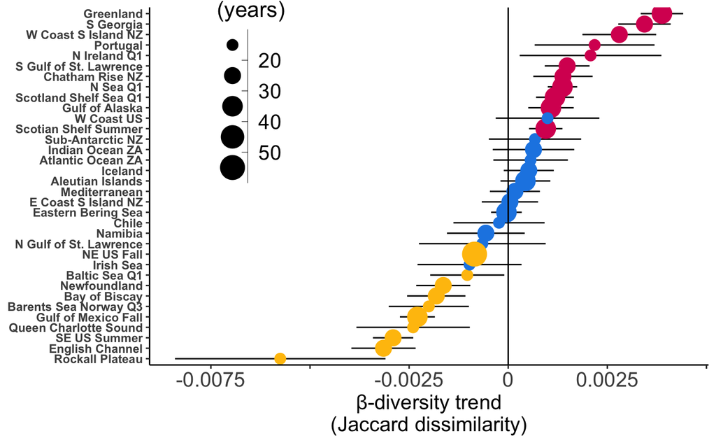

```r
jaccard_total_coefs.r[,Directional_Change_sig := ifelse(differentiating > 0, "Differentiation",ifelse(homogenizing > 0 , "Homogenization", "No β-diversity trend"))]
years_sampled <- unique(jaccard_index_allyears[,.(survey_unit, years_sampled)])
jaccard_total_coefs.r <- years_sampled[jaccard_total_coefs.r, on = "survey_unit"]

(jaccard_total_Dissimilarity_Coef_errorbar_reduced_colorbytrend_LINEAR_MODEL <- ggplot(data = jaccard_total_coefs.r, aes(x = reorder(Survey_Name_Season, estimate) , y = estimate), label = Survey_Name_Season) +
    geom_errorbar(aes(ymin = lwr, ymax = upr), fill = "grey", width = 0) + #add confidence intervals
  geom_point(aes(size = years_sampled, color = Directional_Change_sig), stat = 'identity') +
  scale_color_manual(values = c("#D81C60","#FFC109","#1E88E5"), name = "β-diversity trend\n(Jaccard dissimilarity)", guide="none") +
  scale_size_binned(range = c(1,8), name = "Survey period length\n(years)") +
  geom_hline(yintercept = 0) +
  scale_y_continuous(breaks = seq(-0.0075, 0.0075, by = 0.0025), labels = c("-0.0075","","-0.0025","0", "0.0025", "",  "")) +
  xlab("Survey unit") +
  ylab("β-diversity trend\n(Jaccard dissimilarity)") + #total jaccard dissimilarity trend
  coord_flip() +
  theme_classic() +
  theme(axis.text.y = element_text(face = "bold"), axis.title.y = element_blank(), axis.text.x = element_text(size = 15), axis.title.x = element_text(size = 15), legend.position = c(0.3,0.8), legend.direction = "vertical", legend.text = element_text(size = 15), legend.title = element_text(size = 16)))
ggsave(jaccard_total_Dissimilarity_Coef_errorbar_reduced_colorbytrend_LINEAR_MODEL,
       path = here::here("figures"), filename = "jaccard_total_Dissimilarity_Coef_errorbar_reduced_colorbytrend_LINEAR_MODEL.jpg", height = 7, width = 7)
```

Jaccard true abundance

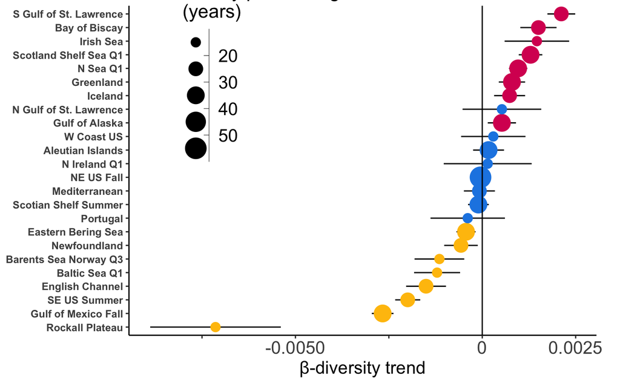

```r
###############
#FOR LINEAR MODEL INSTEAD OF LINEAR MIXED EFFECTS as of fall 2023
###############

jaccard_abundance_total_coefs.r[,Directional_Change_sig := ifelse(differentiating > 0, "Differentiation",ifelse(homogenizing > 0 , "Homogenization", "No β-diversity trend"))]
years_sampled <- unique(jaccard_index_allyears[,.(survey_unit, years_sampled)])
jaccard_abundance_total_coefs.r <- years_sampled[jaccard_abundance_total_coefs.r, on = "survey_unit"]

(Jaccard_abundance_Dissimilarity_Coef_errorbar_reduced_colorbytrend_LINEAR_MODEL <- ggplot(data = jaccard_abundance_total_coefs.r, aes(x = reorder(Survey_Name_Season, estimate) , y = estimate), label = Survey_Name_Season) +
    geom_errorbar(aes(ymin = lwr, ymax = upr), fill = "grey", width = 0) + #add confidence intervals
  geom_point(aes(size = years_sampled, color = Directional_Change_sig), stat = 'identity') +
  scale_color_manual(values = c("#D81C60","#FFC109","#1E88E5"), name = "Dissimilarity trend", guide="none") +
  scale_size_binned(range = c(1,8), name = "Survey period length\n(years)") +
  geom_hline(yintercept = 0) +
  scale_y_continuous(breaks = seq(-0.01, 0.005, by = 0.0025), labels = c("-0.0010","","-0.0050","","0", "0.0025","0.0050")) +
  xlab("Survey unit") +
  ylab("β-diversity trend") +
  coord_flip() +
  theme_classic() +
  theme(axis.text.y = element_text(face = "bold"), axis.title.y = element_blank(), axis.text.x = element_text(size = 15), axis.title.x = element_text(size = 15), legend.position = c(0.3,0.8), legend.direction = "vertical", legend.text = element_text(size = 15), legend.title = element_text(size = 16), plot.margin = margin(5,20,5,5,unit = "pt")))
ggsave(Jaccard_abundance_Dissimilarity_Coef_errorbar_reduced_colorbytrend_LINEAR_MODEL,
       path = here::here("figures"), filename = "Jaccard_abundance_Dissimilarity_Coef_errorbar_reduced_colorbytrend_LINEAR_MODEL.jpg", height = 7, width = 7)
```

```r
#plot for legend
directional_change_legend_plot_colorbytrend <- Jaccard_abundance_Dissimilarity_Coef_errorbar_reduced_colorbytrend_LINEAR_MODEL +
  theme(legend.position = "right", legend.background = element_rect(fill= "transparent"),
         legend.text = element_text(size = 15), legend.title = element_text(size = 16)) +
  guides(colour = guide_legend(override.aes = list(size=6)), size = "none")
```

Jaccard relative abundance

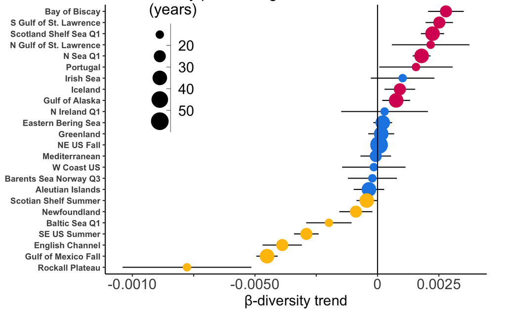

```r
jaccard_relative_abundance_total_coefs.r[,Directional_Change_sig := ifelse(differentiating > 0, "Differentiation",ifelse(homogenizing > 0 , "Homogenization", "No β-diversity trend"))]
years_sampled <- unique(jaccard_index_allyears[,.(survey_unit, years_sampled)])
jaccard_relative_abundance_total_coefs.r <- years_sampled[jaccard_relative_abundance_total_coefs.r, on = "survey_unit"]

(Jaccard_relative_abundance_Dissimilarity_Coef_errorbar_reduced_colorbytrend_LINEAR_MODEL <- ggplot(data = jaccard_relative_abundance_total_coefs.r, aes(x = reorder(Survey_Name_Season, estimate) , y = estimate), label = Survey_Name_Season) +
    geom_errorbar(aes(ymin = lwr, ymax = upr), fill = "grey", width = 0) + #add confidence intervals
  geom_point(aes(size = years_sampled, color = Directional_Change_sig), stat = 'identity') +
  scale_color_manual(values = c("#D81C60","#FFC109","#1E88E5"), name = "Dissimilarity trend", guide="none") +
  scale_size_binned(range = c(1,8), name = "Survey period length\n(years)") +
  geom_hline(yintercept = 0) +
  scale_y_continuous(breaks = seq(-0.01, 0.005, by = 0.0025), labels = c("-0.0010","","-0.0050","","0", "0.0025","0.0050")) +
  xlab("Survey unit") +
  ylab("β-diversity trend") + #total BC dissimilarity trend
  coord_flip() +
  theme_classic() +
  theme(axis.text.y = element_text(face = "bold"), axis.title.y = element_blank(), axis.text.x = element_text(size = 15), axis.title.x = element_text(size = 15), legend.position = c(0.3,0.8), legend.direction = "vertical", legend.text = element_text(size = 15), legend.title = element_text(size = 16), plot.margin = margin(5,20,5,5,unit = "pt")))
ggsave(Jaccard_relative_abundance_Dissimilarity_Coef_errorbar_reduced_colorbytrend_LINEAR_MODEL,
       path = here::here("figures"), filename = "Jaccard_relative_abundance_Dissimilarity_Coef_errorbar_reduced_colorbytrend_LINEAR_MODEL.jpg", height = 7, width = 7)
```

```r
#plot for legend
directional_change_legend_plot_colorbytrend <- Jaccard_relative_abundance_Dissimilarity_Coef_errorbar_reduced_colorbytrend_LINEAR_MODEL +
  theme(legend.position = "right", legend.background = element_rect(fill= "transparent"),
         legend.text = element_text(size = 15), legend.title = element_text(size = 16)) +
  guides(colour = guide_legend(override.aes = list(size=6)), size = "none")
```

#Figure to merge three metrics for supplement

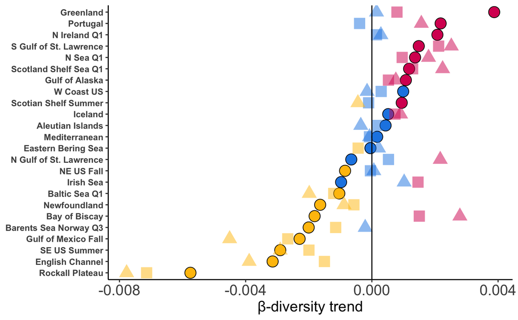

```r
jaccard_total_coefs.r[,jaccard_coefficient := estimate][,Directional_Change_sig_jaccard := Directional_Change_sig]
all_total_coefs <- jaccard_total_coefs.r[,.(survey_unit, Survey_Name_Season, jaccard_coefficient, Directional_Change_sig_jaccard, trend_color_jaccard)]

#add jaccard abundance metrics
jaccard_abundance_total_coefs.r[,jaccard_abundance_coefficient := estimate][,Directional_Change_sig_jaccard_abundance := Directional_Change_sig]
jaccard_abundance_total_coefs.r.r <- jaccard_abundance_total_coefs.r[,.(survey_unit, jaccard_abundance_coefficient, Directional_Change_sig_jaccard_abundance, trend_color_jaccard_abundance)]
all_total_coefs <- all_total_coefs[jaccard_abundance_total_coefs.r.r, on = "survey_unit"]

#add relative jaccard abundance metrics
jaccard_relative_abundance_total_coefs.r[,jaccard_abundance_relative_coefficient := estimate][,Directional_Change_sig_jaccard_abundance_relative := Directional_Change_sig]
jaccard_relative_abundance_total_coefs.r.r <- jaccard_relative_abundance_total_coefs.r[,.(survey_unit, jaccard_abundance_relative_coefficient, Directional_Change_sig_jaccard_abundance_relative, trend_color_jaccard_relative_abundance)]
all_total_coefs <- all_total_coefs[jaccard_relative_abundance_total_coefs.r.r, on = "survey_unit"]

#plot
(Dissimilarity_Coef_errorbar_reduced_colorbytrend_LINEAR_MODEL_comparison <- ggplot(data = all_total_coefs, aes(x = reorder(Survey_Name_Season, jaccard_coefficient)), label = Survey_Name_Season) +
  geom_point(aes(y = jaccard_coefficient, fill = Directional_Change_sig_jaccard), stat = 'identity',shape = 21, color = "black", size = 5) +
  geom_point(aes(y = jaccard_abundance_coefficient, color = Directional_Change_sig_jaccard_abundance), stat = 'identity', shape = 15, alpha = 0.5,size = 5) +
  geom_point(aes(y = jaccard_abundance_relative_coefficient, color = Directional_Change_sig_jaccard_abundance_relative), stat = 'identity', shape = 17, alpha = 0.5,size = 5) +
  scale_color_manual(values = c("#D81C60","#FFC109","#1E88E5"), name = "β-diversity trend", guide="none") +
  scale_fill_manual(values = c("#D81C60","#FFC109","#1E88E5"), name = "β-diversity trend", guide="none") +
  geom_hline(yintercept = 0) +
 # scale_y_continuous(breaks = seq(-0.0075, 0.0075, by = 0.0025), labels = c("-0.0075","","-0.0025","0", "0.0025", "",  "")) +
  xlab("Survey unit") +
  ylab("β-diversity trend") + #total jaccard dissimilarity trend
  coord_flip() +
  theme_classic() +
  theme(axis.text.y = element_text(face = "bold"), axis.title.y = element_blank(), axis.text.x = element_text(size = 15), axis.title.x = element_text(size = 15), legend.position = c(0.3,0.8), legend.direction = "vertical", legend.text = element_text(size = 15), legend.title = element_text(size = 16)))

ggsave(Dissimilarity_Coef_errorbar_reduced_colorbytrend_LINEAR_MODEL_comparison,
       path = here::here("figures"), filename = "Dissimilarity_Coef_errorbar_reduced_colorbytrend_LINEAR_MODEL_comparison.jpg", height = 7, width = 7)
```

##Wavy Line Plot for GAMs (Figure 2a)

Generate predicted values (this datatable will hold all jaccard metrics)

```r
#generate list again, as for some reason it doesn't stay in environment
survey_unit.list <- levels(factor(jaccard_index_allyears$survey_unit))

#generate new data to smooth lines (need year and season survey combinations)
year_survey_unit_expand.dt <- data.table(survey_unit = as.character(NULL), year = as.numeric(NULL), year_adj = as.numeric(NULL ))

for (i in 1:length(survey_unit.list)) {
  #generate year vectors
  survey_unit_years <- unique(jaccard_index_allyears[survey_unit == survey_unit.list[i],.(survey_unit, year, year_adj)])

  years <- seq(min(survey_unit_years[,year]), max(survey_unit_years[,year]), by = 0.1)

  year_adjust <- seq(min(survey_unit_years[,year_adj]), max(survey_unit_years[,year_adj]), by = 0.1)

  year_survey_unit_expand.dt_addition <- data.table(survey_unit = survey_unit.list[i], year = years, year_adj = year_adjust)

  year_survey_unit_expand.dt <- rbind(year_survey_unit_expand.dt, year_survey_unit_expand.dt_addition)
}


#add colors and names to full year and survey unit combination table
year_survey_unit_expand_jaccard.dt <- year_survey_unit_expand.dt[color_link_trend_jaccard, on = "survey_unit"]
```

Jaccard Get model as predictions

```r
#for plotting, get model as predictions
jaccard_total_gam_predictions <- predict(jaccard_total_gam, se.fit = TRUE, newdata = year_survey_unit_expand_jaccard.dt)

#merge into table
year_survey_unit_expand_jaccard.dt[,jaccard_glm_mod_fit := jaccard_total_gam_predictions$fit][,jaccard_glm_mod_fit_SE := jaccard_total_gam_predictions$se.fit]
```

##Color GAMs by trend (year vs dissimilarity) ###Jaccard dissimilarity

```r
#link distances dissimilarities with trend color hex
jaccard_index_allyears_jaccard <- jaccard_index_allyears[color_link_trend_jaccard, on = "survey_unit"]
jaccard_index_allyears_jaccard<- jaccard_index_allyears_jaccard[dissimilarity_metric == "jaccard_dissimilarity_index_binary"]

#change survey_unit to factor
jaccard_index_allyears_jaccard[,survey_unit := factor(survey_unit)]
year_survey_unit_expand_jaccard.dt[,survey_unit := factor(survey_unit)]

#check that survey_unit in alpha order
sort(unique(jaccard_index_allyears_jaccard$survey_unit)) == levels(jaccard_index_allyears_jaccard$survey_unit)
```

```
 [1] TRUE TRUE TRUE TRUE TRUE TRUE TRUE TRUE TRUE TRUE TRUE TRUE TRUE TRUE TRUE TRUE TRUE TRUE TRUE
[20] TRUE TRUE TRUE TRUE TRUE TRUE TRUE TRUE TRUE TRUE TRUE TRUE TRUE TRUE TRUE
```

```r
sort(unique(year_survey_unit_expand_jaccard.dt$survey_unit)) == levels(year_survey_unit_expand_jaccard.dt$survey_unit)
```

```
 [1] TRUE TRUE TRUE TRUE TRUE TRUE TRUE TRUE TRUE TRUE TRUE TRUE TRUE TRUE TRUE TRUE TRUE TRUE TRUE
[20] TRUE TRUE TRUE TRUE TRUE TRUE TRUE TRUE TRUE TRUE TRUE TRUE TRUE TRUE TRUE
```

```r
#get list of colors in the right order
trend_colors_jaccard.dt <- unique(jaccard_index_allyears_jaccard[dissimilarity_metric == "jaccard_dissimilarity_index_binary",.(survey_unit, Survey_Name_Season, trend_color_jaccard)])

#make sure it matches year_survey_unit_expand.dt
all(trend_colors_jaccard.dt == unique(year_survey_unit_expand_jaccard.dt[,.(survey_unit, Survey_Name_Season, trend_color_jaccard)]))
```

```
[1] TRUE
```

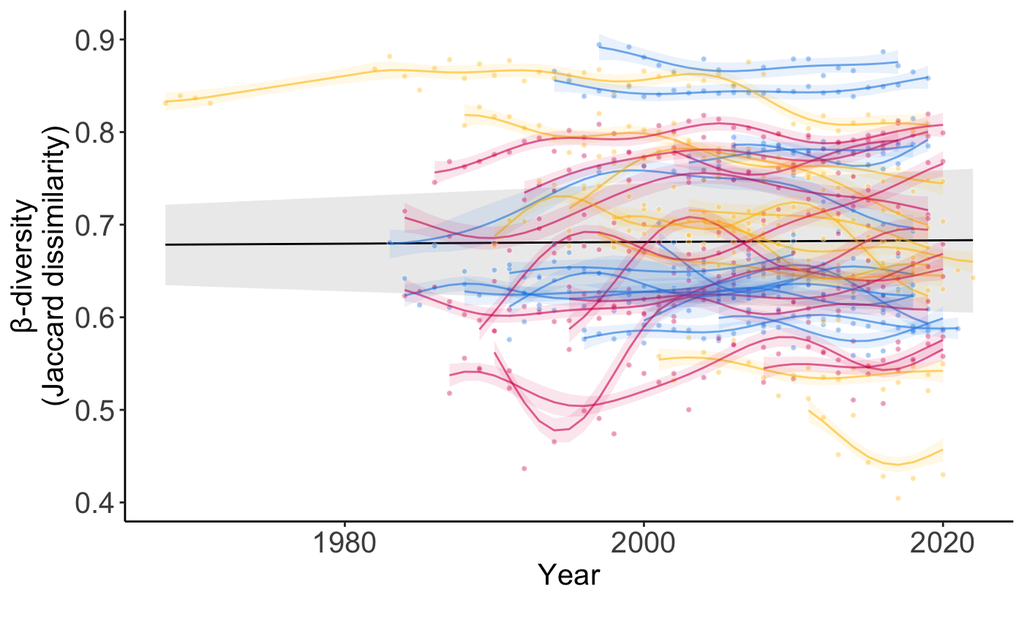

```r
setorder(trend_colors_jaccard.dt, survey_unit)


points_wavylines_jaccard_total_year_reduced_gam_colorbytrend <- ggplot() +
  #full LMER predictions (black)
  geom_ribbon(data = lmer_jaccard_total_predictions, aes(x = year, ymin = jaccard_lmer_preds_lowerCI, ymax = jaccard_lmer_preds_upperCI), fill = "grey", alpha = 0.3) +
    geom_line(data = lmer_jaccard_total_predictions, aes(x = year, y = jaccard_lmer_preds), color = "black") +
  #points by trend
  geom_point(data = jaccard_index_allyears[dissimilarity_metric =="jaccard_dissimilarity_index_binary"], cols = "year_adj",
             aes(x = year,
                 y = annual_dissimilarity_value,
                 fill = survey_unit), alpha = 0.4, size = 1, shape = 21, color = "white") +
  #squiggly lines by survey unit based GAM and colored by trend
    geom_line(data = year_survey_unit_expand_jaccard.dt, cols = "year_adj",
             aes(x = year,
                 y = jaccard_glm_mod_fit,
                 color = survey_unit), alpha = 0.6) +
  #confidence intervals for individual GAM
  geom_ribbon(data = year_survey_unit_expand_jaccard.dt, cols = "year_adj",
              aes(x = year, ymin=jaccard_glm_mod_fit-jaccard_glm_mod_fit_SE, ymax=jaccard_glm_mod_fit+jaccard_glm_mod_fit_SE, fill =  survey_unit), alpha=0.1) + #add standard error
  #set color by survey
    scale_color_manual(values = trend_colors_jaccard.dt$trend_color, name = "Survey Unit") +
  scale_fill_manual(values =trend_colors_jaccard.dt$trend_color, guide = "none") +
  theme_classic() +
  lims(x = c(min(jaccard_index_allyears[dissimilarity_metric == "jaccard_dissimilarity_index_binary",year]),max(jaccard_index_allyears[dissimilarity_metric == "jaccard_dissimilarity_index_binary",year]))
       ) +
  xlab("Year\n") +
ylab("β-diversity\n(Jaccard dissimilarity)") +
  theme(legend.position = "null", axis.text = element_text(size = 15), axis.title = element_text(size = 15))
points_wavylines_jaccard_total_year_reduced_gam_colorbytrend

ggsave(points_wavylines_jaccard_total_year_reduced_gam_colorbytrend, path = here::here("figures"), filename ="points_wavylines_jaccard_total_year_reduced_gam_colorbytrend.jpg", height = 6, width = 11, unit = "in")
```

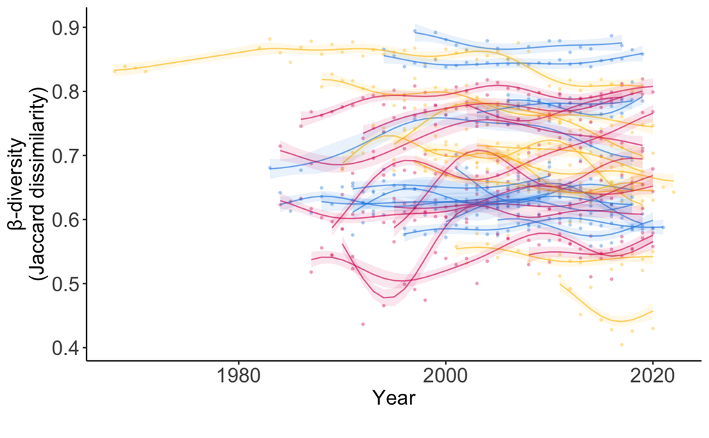

```r
#Same, but no GAM
points_wavylines_jaccard_total_year_reduced_gam_colorbytrend_notrend <- ggplot() +
  #points by trend
  geom_point(data = jaccard_index_allyears[dissimilarity_metric =="jaccard_dissimilarity_index_binary"], cols = "year_adj",
             aes(x = year,
                 y = annual_dissimilarity_value,
                 fill = survey_unit), alpha = 0.4, size = 1, shape = 21, color = "white") +
  #squiggly lines by survey unit based GAM and colored by trend
    geom_line(data = year_survey_unit_expand_jaccard.dt, cols = "year_adj",
             aes(x = year,
                 y = jaccard_glm_mod_fit,
                 color = survey_unit), alpha = 0.6) +
  #confidence intervals for individual GAM
  geom_ribbon(data = year_survey_unit_expand_jaccard.dt, cols = "year_adj",
              aes(x = year, ymin=jaccard_glm_mod_fit-jaccard_glm_mod_fit_SE, ymax=jaccard_glm_mod_fit+jaccard_glm_mod_fit_SE, fill =  survey_unit), alpha=0.1) + #add standard error
  #set color by survey
    scale_color_manual(values = trend_colors_jaccard.dt$trend_color, name = "Survey Unit") +
  scale_fill_manual(values =trend_colors_jaccard.dt$trend_color, guide = "none") +
  theme_classic() +
  lims(x = c(min(jaccard_index_allyears[dissimilarity_metric == "jaccard_dissimilarity_index_binary",year]),max(jaccard_index_allyears[dissimilarity_metric == "jaccard_dissimilarity_index_binary",year]))
       ) +
  xlab("Year\n") +
ylab("β-diversity\n(Jaccard dissimilarity)") +
  theme(legend.position = "null", axis.text = element_text(size = 15), axis.title = element_text(size = 15))
points_wavylines_jaccard_total_year_reduced_gam_colorbytrend_notrend

ggsave(points_wavylines_jaccard_total_year_reduced_gam_colorbytrend_notrend, path = here::here("figures"), filename ="points_wavylines_jaccard_total_year_reduced_gam_colorbytrend_notrend.jpg", height = 6, width = 11, unit = "in")
```

##Split out individual example regions for presentation Iceland “#1E88E5”, West Coast South Island, & West Atlantic

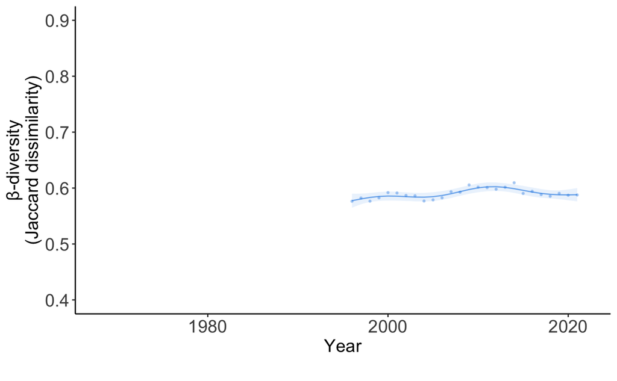

```r
#Iceland
points_wavylines_jaccard_total_year_reduced_gam_colorbytrend_ICELAND <- ggplot() +
  geom_point(data = jaccard_index_allyears[dissimilarity_metric =="jaccard_dissimilarity_index_binary" & survey_unit == "ICE-GFS"], cols = "year_adj",
             aes(x = year,
                 y = annual_dissimilarity_value), fill = "#1E88E5",alpha = 0.4, size = 1, shape = 21, color = "white") +
  #squiggly lines by survey unit based GAM and colored by trend
    geom_line(data = year_survey_unit_expand_jaccard.dt[survey_unit == "ICE-GFS"], cols = "year_adj",
             aes(x = year,
                 y = jaccard_glm_mod_fit), color = "#1E88E5", alpha = 0.6) +
  #confidence intervals for individual GAM
  geom_ribbon(data = year_survey_unit_expand_jaccard.dt[survey_unit == "ICE-GFS"], cols = "year_adj",
              aes(x = year, ymin=jaccard_glm_mod_fit-jaccard_glm_mod_fit_SE, ymax=jaccard_glm_mod_fit+jaccard_glm_mod_fit_SE), alpha=0.1, fill = "#1E88E5") + #add standard error
  theme_classic() +
  lims(x = c(min(jaccard_index_allyears[dissimilarity_metric == "jaccard_dissimilarity_index_binary",year]),max(jaccard_index_allyears[dissimilarity_metric == "jaccard_dissimilarity_index_binary",year])), y = c(0.4,0.9)
       ) +
  xlab("Year\n") +
ylab("β-diversity\n(Jaccard dissimilarity)") +
  theme(legend.position = "null", axis.text = element_text(size = 15), axis.title = element_text(size = 15))
points_wavylines_jaccard_total_year_reduced_gam_colorbytrend_ICELAND

ggsave(points_wavylines_jaccard_total_year_reduced_gam_colorbytrend_ICELAND, path = here::here("figures"), filename ="points_wavylines_jaccard_total_year_reduced_gam_colorbytrend_ICELAND.jpg", height = 6, width = 11, unit = "in")
```